# DTAS 6101

## **Chapter 1: Introduction**

Cardiovascular disease (CVD) is a class of disease that involves the heart or blood vessels. CVD includes coronary artery diseases (CAD) such as Angina and Myocardial Infarction (commonly known as heart attack).

Other CVDs include stroke, heart failure, hypertensive heart disease, rheumatic heart disease, cardiomyopathy, abnormal heart rhythms, congenital heart disease, etc.

On a global scale, CVDs are the leading cause of death. Altogether, CVD has resulted in 17.9 million deaths (32.1%) in 2015, which is an increment from 12.3 million (25.8%) in 1990.

Deaths at a given age, from CVD, are more common and have been increasing in today’s day and age.

Through this project and analysis, we aim to identify the factors which cause Cardiovascular diseases in adults.

### SMART QUESTIONS

1. Can age be a factor?
2. How important are alcohol and smoking in affecting Cardiovascular Diseases?
3. Apart from the most obvious factors, what other aspects of Gender can affect the risk of CVD?

## **Chapter 2: Data Cleaning**

```r
fivenum(cd$age)
```

```
## [1] 30 48 54 58 65
```

```r
psych::describe(cd$age)
```

```
##    vars     n  mean   sd median trimmed  mad min max range  skew kurtosis
## X1    1 70000 53.34 6.77     54   53.62 7.41  30  65    35 -0.31    -0.82
##      se
## X1 0.03
```

```r
stat.desc(cd$age)
```

```
##      nbr.val     nbr.null       nbr.na          min          max
## 7.000000e+04 0.000000e+00 0.000000e+00 3.000000e+01 6.500000e+01
##        range          sum       median         mean      SE.mean
## 3.500000e+01 3.733708e+06 5.400000e+01 5.333869e+01 2.557041e-02
## CI.mean.0.95          var      std.dev     coef.var
## 5.011795e-02 4.576920e+01 6.765294e+00 1.268365e-01
```

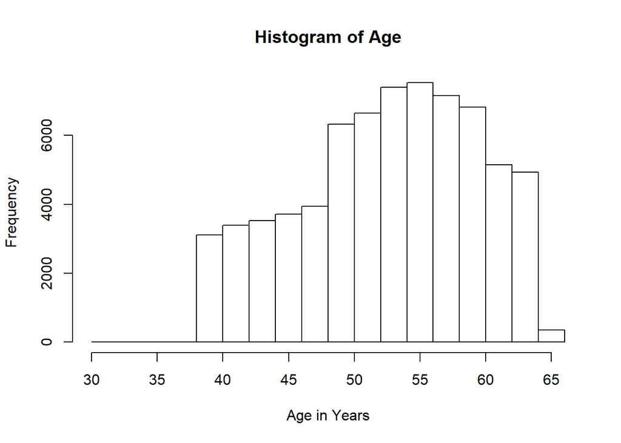

```r
hist(cd$age,
     main = "Histogram of Age",
     xlab = "Age in Years")
```

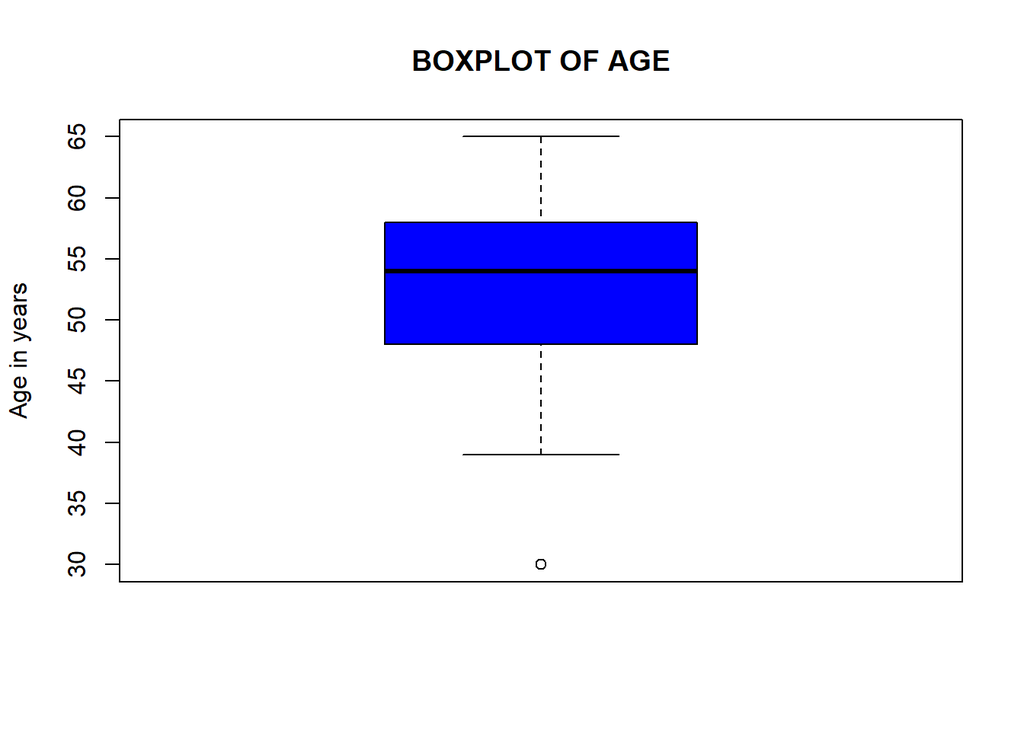

```r
boxplot(cd$age,
        main = toupper("Boxplot of Age"),
        ylab = "Age in years",
        col = "blue")
```

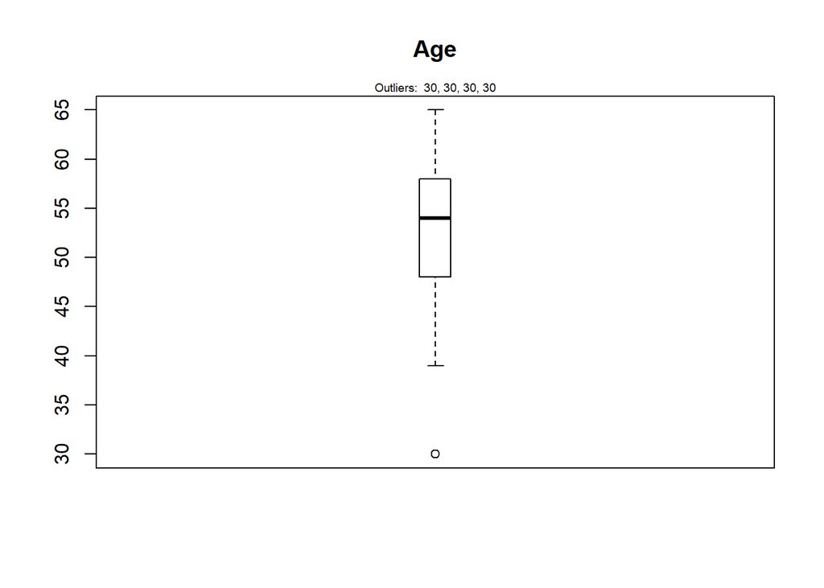

```r
outlier_values <- boxplot.stats(cd$age)$out  # outlier values.
boxplot(cd$age, main="Age", boxwex=0.1)
mtext(paste("Outliers: ", paste(outlier_values, collapse=", ")), cex=0.6)
```

As we can see skewness in -0.3 which means age is approximately symmetric. As if skewness is in between scale of (-0.5 to 0.5)it will be considered approximately symmetric.

#### so in age as we can see the outliers are value 30 which are outside of 1.5*IQR . We are going to use capping methiod in order to treat outlier. For missing values that lie outside the 1.5*IQR limits, we could cap it by replacing those observations outside the lower limit with the value of 5th %ile and those that lie above the upper limit, with the value of 95th %ile.

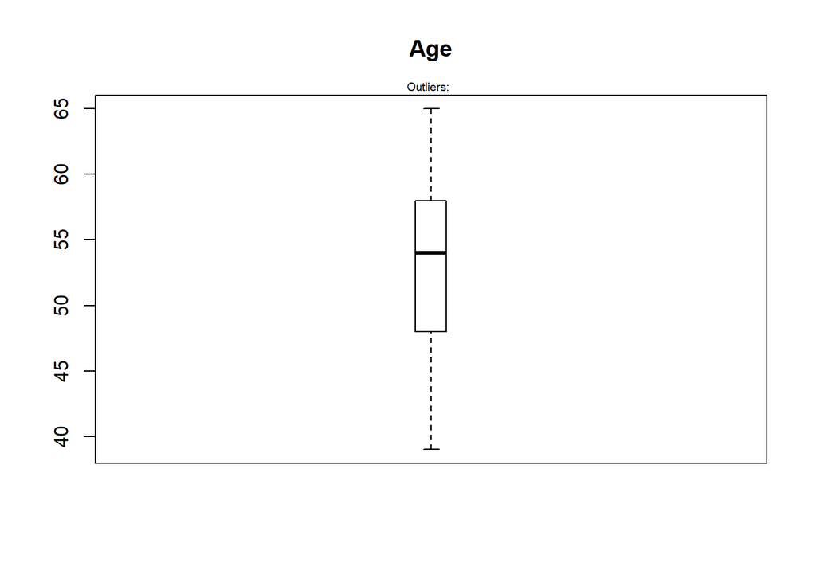

```r
qnt <- quantile(cd$age, probs=c(.25, .75), na.rm = T)
caps <- quantile(cd$age, probs=c(.05, .95), na.rm = T)
H <- 1.5 * IQR(cd$age, na.rm = T)
cd$age[cd$age < (qnt[1] - H)] <- caps[1]
cd$age[cd$age > (qnt[2] + H)] <- caps[2]

outlier_values <- boxplot.stats(cd$age)$out  # outlier values.
boxplot(cd$age, main="Age", boxwex=0.1)
mtext(paste("Outliers: ", paste(outlier_values, collapse=", ")), cex=0.6)
```

#### As we can see now the age column has no outliers.we are good to go.

```r
fivenum(cd$height)
```

```
## [1]  55 159 165 170 250
```

```r
psych::describe(cd$height)
```

```
##    vars     n   mean   sd median trimmed  mad min max range  skew kurtosis
## X1    1 70000 164.36 8.21    165  164.32 7.41  55 250   195 -0.64     7.94
##      se
## X1 0.03
```

```r
stat.desc(cd$height)
```

```
##      nbr.val     nbr.null       nbr.na          min          max
## 7.000000e+04 0.000000e+00 0.000000e+00 5.500000e+01 2.500000e+02
##        range          sum       median         mean      SE.mean
## 1.950000e+02 1.150515e+07 1.650000e+02 1.643592e+02 3.103136e-02
## CI.mean.0.95          var      std.dev     coef.var
## 6.082140e-02 6.740617e+01 8.210126e+00 4.995233e-02
```

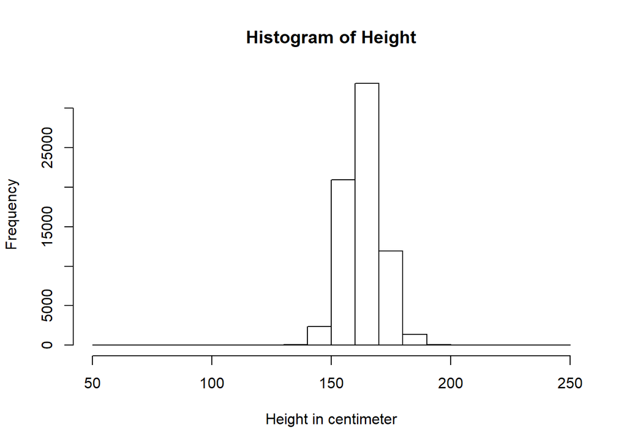

```r
hist(cd$height,
     main = "Histogram of Height",
     xlab = "Height in centimeter")
```

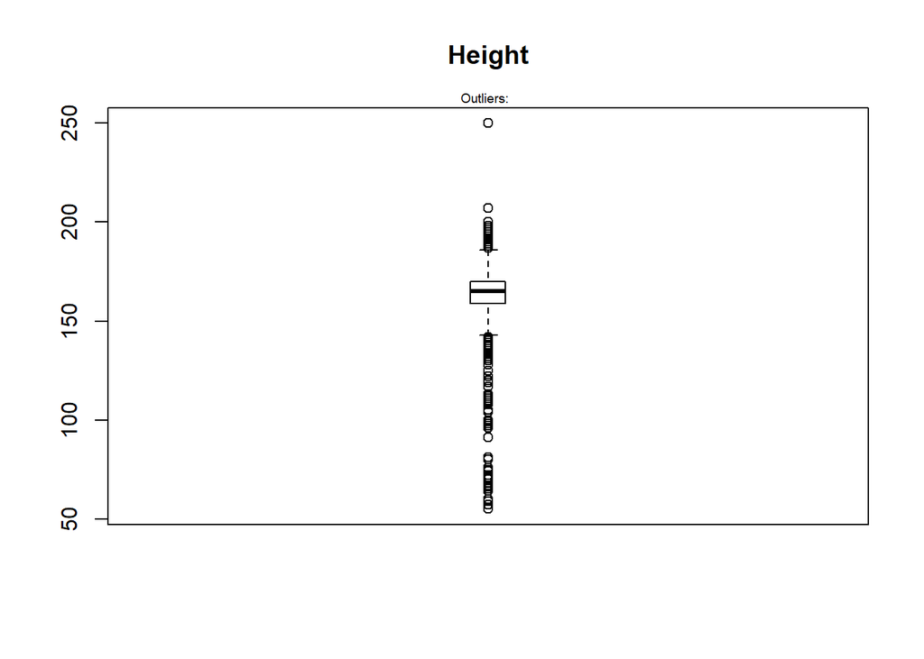

```r
outlier_values <- boxplot.stats(cd$cd$height)$out  # outlier values.
boxplot(cd$height, main="Height", boxwex=0.1)
mtext(paste("Outliers: ", paste(outlier_values, collapse=", ")), cex=0.6)
```

```r
outliersper <- function(x){
  length(which(x >  mean(x) + 3 * sd(x) | x < mean(x) - 3 * sd(x))  ) / length(x)
}

print(outliersper(cd$height))
```

```
## [1] 0.004185714
```

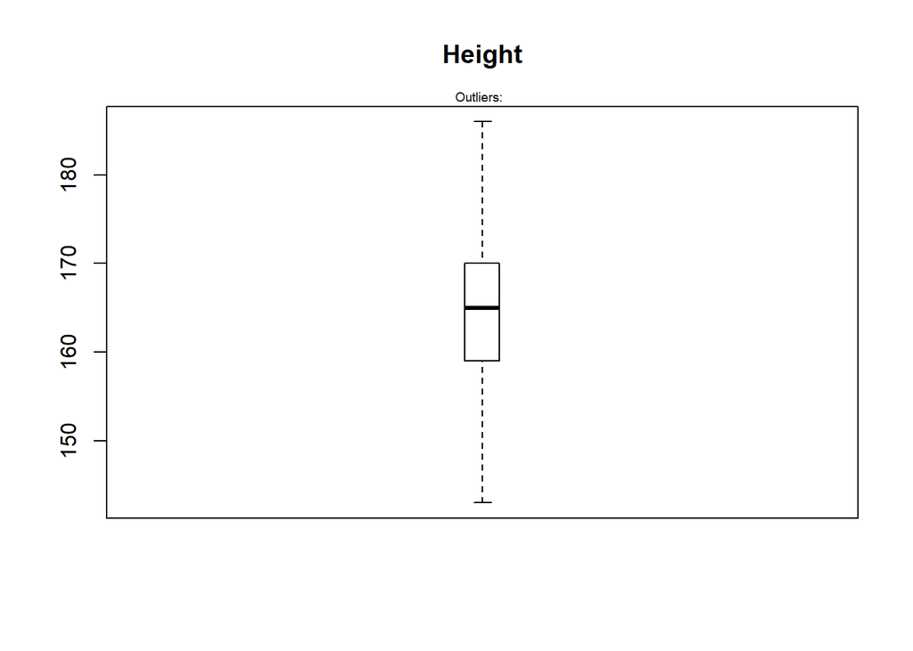

```r
qnt <- quantile(cd$height, probs=c(.25, .75), na.rm = T)
caps <- quantile(cd$height, probs=c(.05, .95), na.rm = T)
H <- 1.5 * IQR(cd$height, na.rm = T)
cd$height[cd$height < (qnt[1] - H)] <- caps[1]
cd$height[cd$height > (qnt[2] + H)] <- caps[2]

outlier_values <- boxplot.stats(cd$height)$out  # outlier values.
boxplot(cd$height, main="Height", boxwex=0.1)
mtext(paste("Outliers: ", paste(outlier_values, collapse=", ")), cex=0.6)
```

```r
fivenum(cd$weight)
```

```
## [1]  10  65  72  82 200
```

```r
psych::describe(cd$weight)
```

```
##    vars     n  mean   sd median trimmed   mad min max range skew kurtosis
## X1    1 70000 74.21 14.4     72   73.11 11.86  10 200   190 1.01     2.59
##      se
## X1 0.05
```

```r
stat.desc(cd$weight)
```

```
##      nbr.val     nbr.null       nbr.na          min          max
## 7.000000e+04 0.000000e+00 0.000000e+00 1.000000e+01 2.000000e+02
##        range          sum       median         mean      SE.mean
## 1.900000e+02 5.194398e+06 7.200000e+01 7.420569e+01 5.441085e-02
## CI.mean.0.95          var      std.dev     coef.var
## 1.066451e-01 2.072378e+02 1.439576e+01 1.939980e-01
```

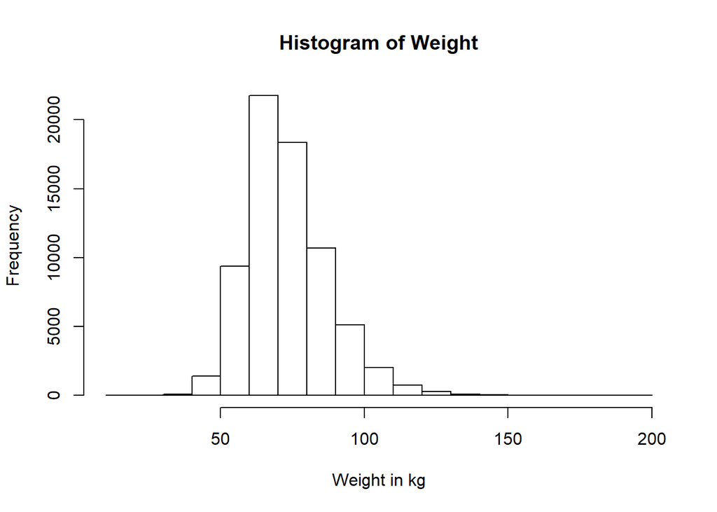

```r
hist(cd$weight,
     main = "Histogram of Weight",
     xlab = "Weight in kg")
```

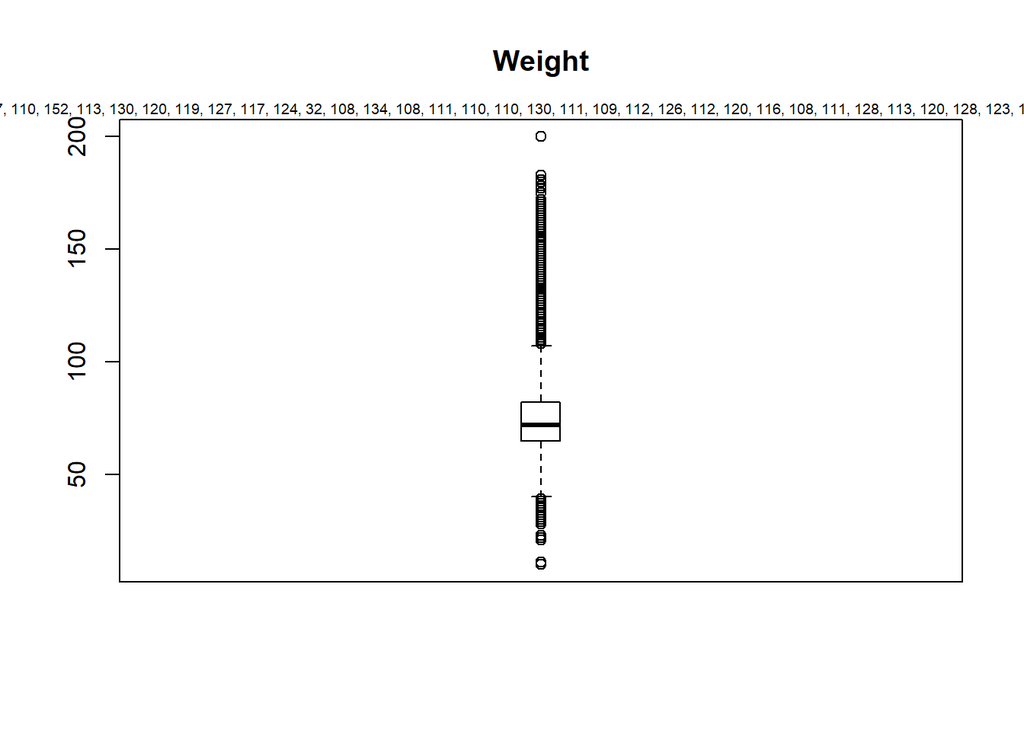

```r
outlier_values <- boxplot.stats(cd$weight)$out  # outlier values.
boxplot(cd$weight, main="Weight", boxwex=0.1)
mtext(paste("Outliers: ", paste(outlier_values, collapse=", ")), cex=0.6)
```

```r
outliersper <- function(x){
  length(which(x >  mean(x) + 3 * sd(x) | x < mean(x) - 3 * sd(x))  ) / length(x)
}

print(outliersper(cd$weight))
```

```
## [1] 0.01002857
```

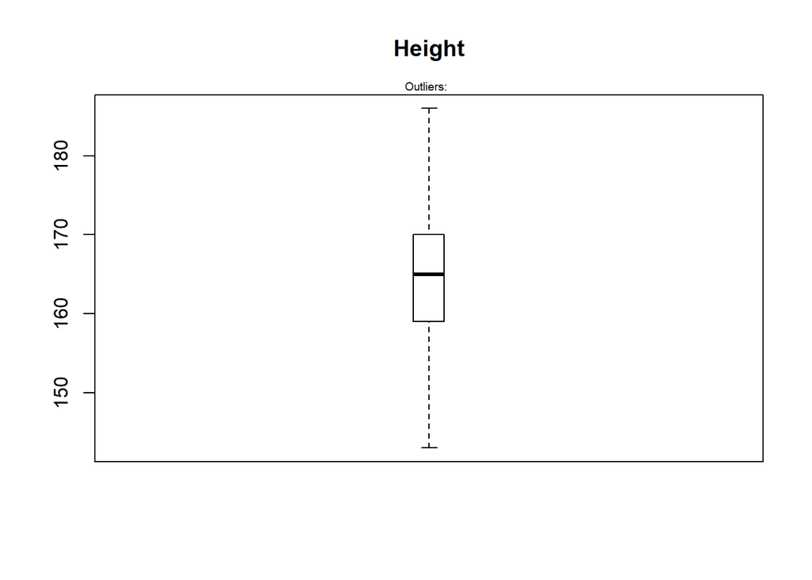

```r
qnt <- quantile(cd$weight, probs=c(.25, .75), na.rm = T)
caps <- quantile(cd$weight, probs=c(.05, .95), na.rm = T)
H <- 1.5 * IQR(cd$weight, na.rm = T)
cd$weight[cd$weight < (qnt[1] - H)] <- caps[1]
cd$weight[cd$weight > (qnt[2] + H)] <- caps[2]

outlier_values <- boxplot.stats(cd$height)$out  # outlier values.
boxplot(cd$height, main="Height", boxwex=0.1)
mtext(paste("Outliers: ", paste(outlier_values, collapse=", ")), cex=0.6)
```

```r
psych::describe(cd$weight)
```

```
##    vars     n  mean    sd median trimmed   mad min max range skew kurtosis
## X1    1 70000 73.75 12.99     72   73.11 11.86  40 107    67 0.39    -0.35
##      se
## X1 0.05
```

#### As we can see now there are no outliers and also skewness is 0.39 which means our data is approximately normal.we are good to go.

```r
fivenum(cd$ap_hi)
```

```
## [1]  -150   120   120   140 16020
```

```r
psych::describe(cd$ap_hi)
```

```
##    vars     n   mean     sd median trimmed   mad  min   max range  skew
## X1    1 70000 128.82 154.01    120   125.6 14.83 -150 16020 16170 85.29
##    kurtosis   se
## X1  7579.32 0.58
```

```r
stat.desc(cd$ap_hi)
```

```
##       nbr.val      nbr.null        nbr.na           min           max
##  7.000000e+04  0.000000e+00  0.000000e+00 -1.500000e+02  1.602000e+04
##         range           sum        median          mean       SE.mean
##  1.617000e+04  9.017210e+06  1.200000e+02  1.288173e+02  5.821084e-01
##  CI.mean.0.95           var       std.dev      coef.var
##  1.140931e+00  2.371952e+04  1.540114e+02  1.195580e+00
```

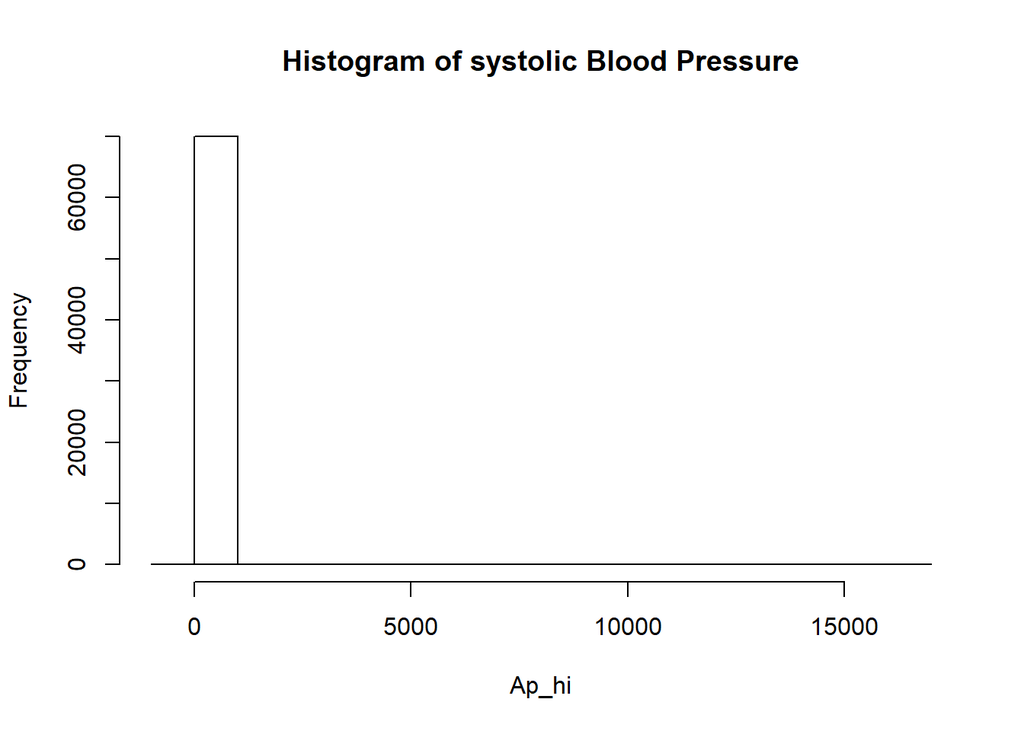

```r
hist(cd$ap_hi,
     main = "Histogram of systolic Blood Pressure",
     xlab = "Ap_hi")
```

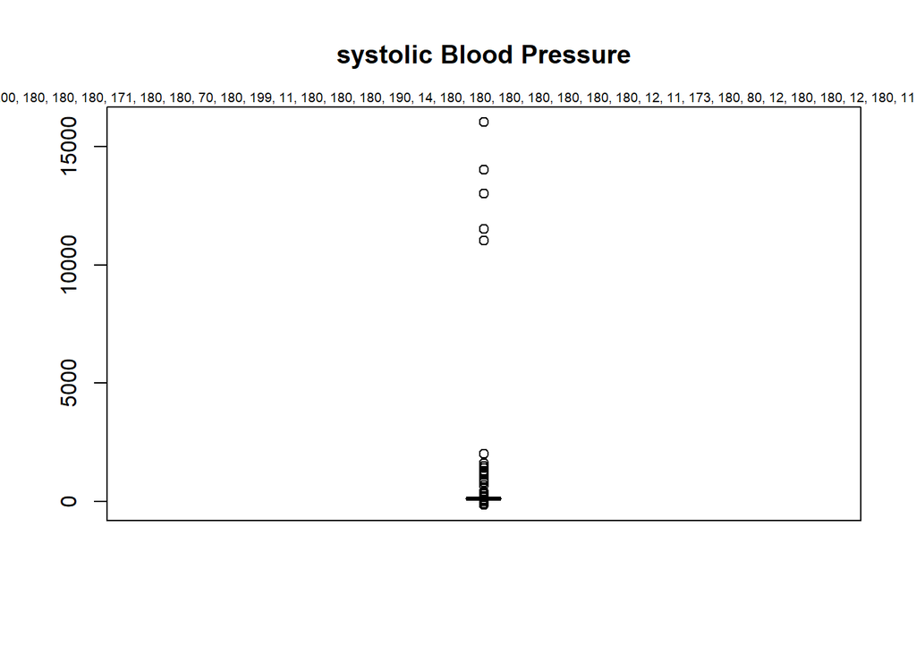

```r
outlier_values <- boxplot.stats(cd$ap_hi)$out  # outlier values.
boxplot(cd$ap_hi, main="systolic Blood Pressure", boxwex=0.1)
mtext(paste("Outliers: ", paste(outlier_values, collapse=", ")), cex=0.6)
```

```r
outliersper <- function(x){
  length(which(x >  mean(x) + 3 * sd(x) | x < mean(x) - 3 * sd(x))  ) / length(x)
}

print(outliersper(cd$ap_hi))
```

```
## [1] 0.0005428571
```

#### As we can see there is a 8 units of difference in mean and Meadian.which is really high . But the outliers are only around .05 % . This means that the values of outliers are of very values. Aslo the skew and kurtosis (85.29,7579.32)values are really very high. which again point to the fact that some values are incorrect or garbage values . we are to going treat the outliers in the next section and then we will analyse our column again.

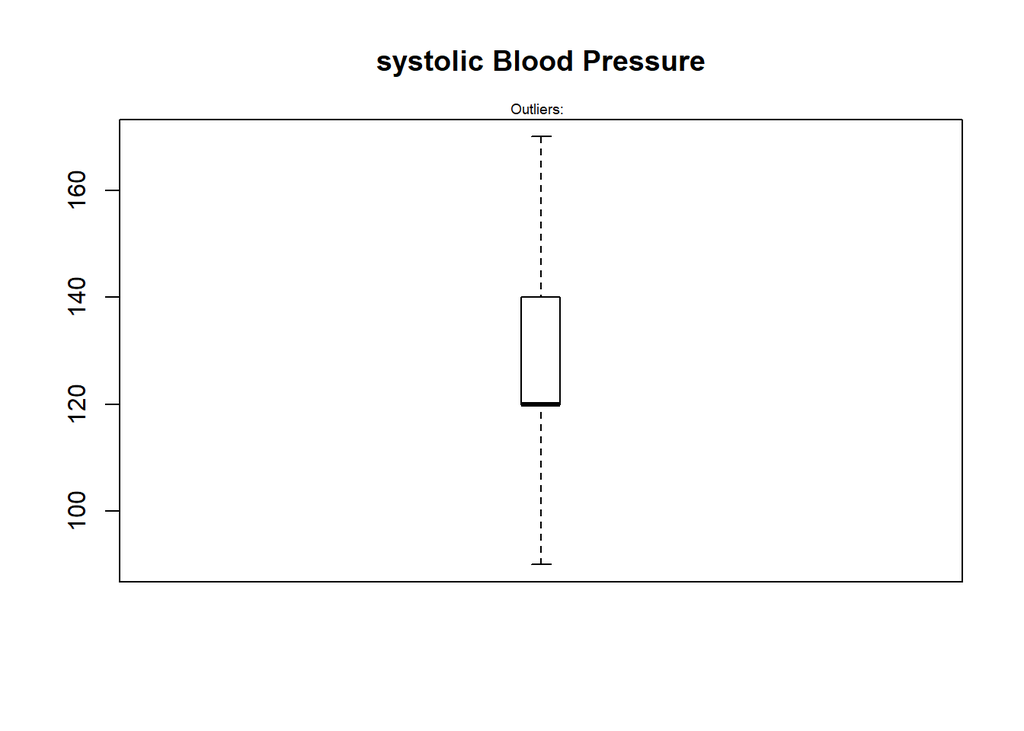

```r
qnt <- quantile(cd$ap_hi, probs=c(.25, .75), na.rm = T)
caps <- quantile(cd$ap_hi, probs=c(.05, .95), na.rm = T)
H <- 1.5 * IQR(cd$ap_hi, na.rm = T)
cd$ap_hi[cd$ap_hi < (qnt[1] - H)] <- caps[1]
cd$ap_hi[cd$ap_hi > (qnt[2] + H)] <- caps[2]

outlier_values <- boxplot.stats(cd$ap_hi)$out  # outlier values.
boxplot(cd$ap_hi, main="systolic Blood Pressure", boxwex=0.1)
mtext(paste("Outliers: ", paste(outlier_values, collapse=", ")), cex=0.6)
```

```r
psych::describe(cd$ap_hi)
```

```
##    vars     n  mean    sd median trimmed   mad min max range skew kurtosis
## X1    1 70000 126.6 15.92    120   125.6 14.83  90 170    80 0.54     0.05
##      se
## X1 0.06
```

```r
fivenum(cd$ap_lo)
```

```
## [1]   -70    80    80    90 11000
```

```r
psych::describe(cd$ap_lo)
```

```
##    vars     n  mean     sd median trimmed  mad min   max range  skew
## X1    1 70000 96.63 188.47     80   81.28 1.48 -70 11000 11070 32.11
##    kurtosis   se
## X1  1425.77 0.71
```

```r
stat.desc(cd$ap_lo)
```

```
##       nbr.val      nbr.null        nbr.na           min           max
##  7.000000e+04  2.100000e+01  0.000000e+00 -7.000000e+01  1.100000e+04
##         range           sum        median          mean       SE.mean
##  1.107000e+04  6.764129e+06  8.000000e+01  9.663041e+01  7.123592e-01
##  CI.mean.0.95           var       std.dev      coef.var
##  1.396223e+00  3.552189e+04  1.884725e+02  1.950447e+00
```

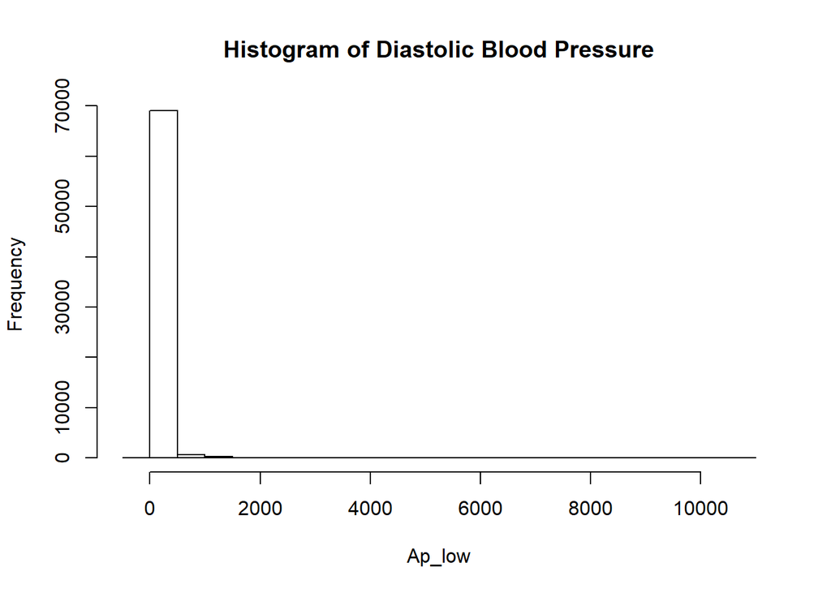

```r
hist(cd$ap_lo,
     main = "Histogram of Diastolic Blood Pressure",
     xlab = "Ap_low")
```

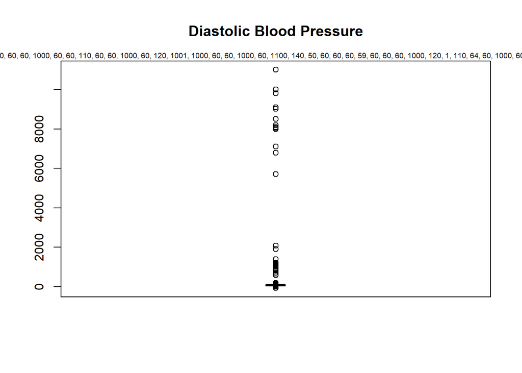

```r
outlier_values <- boxplot.stats(cd$ap_lo)$out  # outlier values.
boxplot(cd$ap_lo, main="Diastolic Blood Pressure", boxwex=0.1)
mtext(paste("Outliers: ", paste(outlier_values, collapse=", ")), cex=0.6)
```

```r
outliersper <- function(x){
  length(which(x >  mean(x) + 3 * sd(x) | x < mean(x) - 3 * sd(x))  ) / length(x)
}

print(outliersper(cd$ap_lo))
```

```
## [1] 0.01358571
```

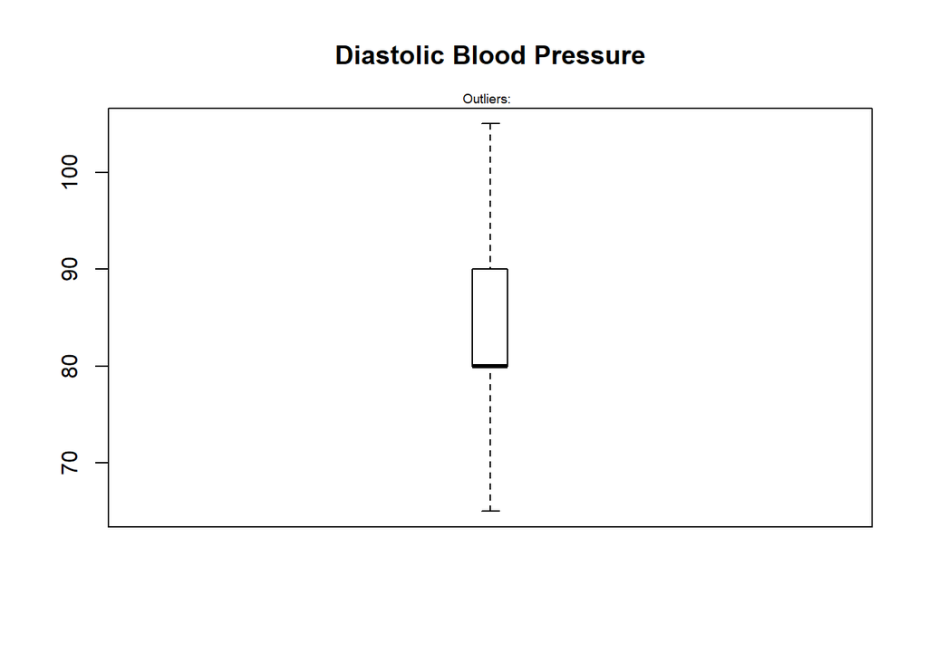

```r
qnt <- quantile(cd$ap_lo, probs=c(.25, .75), na.rm = T)
caps <- quantile(cd$ap_lo, probs=c(.05, .95), na.rm = T)
H <- 1.5 * IQR(cd$ap_lo, na.rm = T)
cd$ap_lo[cd$ap_lo < (qnt[1] - H)] <- caps[1]
cd$ap_lo[cd$ap_lo > (qnt[2] + H)] <- caps[2]

outlier_values <- boxplot.stats(cd$ap_lo)$out  # outlier values.
boxplot(cd$ap_lo, main="Diastolic Blood Pressure", boxwex=0.1)
mtext(paste("Outliers: ", paste(outlier_values, collapse=", ")), cex=0.6)
```

```r
psych::describe(cd$ap_lo)
```

```
##    vars     n  mean   sd median trimmed  mad min max range skew kurtosis
## X1    1 70000 81.87 8.43     80   81.28 1.48  65 105    40 0.48    -0.23
##      se
## X1 0.03
```

#### As we can see now after treatment of outliers , skew has also been in expected range(0.48) . now our variable is approximately normally distributed.

#### Missing Value check and treatment on continous variables

```r
sum(is.na(cd$age))
```

```
## [1] 0
```

```r
sum(is.na(cd$height))
```

```
## [1] 0
```

```r
sum(is.na(cd$weight))
```

```
## [1] 0
```

```r
sum(is.na(cd$ap_hi))
```

```
## [1] 0
```

```r
sum(is.na(cd$ap_lo))
```

```
## [1] 0
```

#### There are no missing variables in the data , which means that we are good to go for our bivariate analysis.

#### Calculating BMI

#### Dropping the id column

#### so we have create 2 dummy variables for cholestrol and 2 dummy variaables for glucose category and in both the columns there are 3 levels

## **Chapter 3: Graphical Representation**

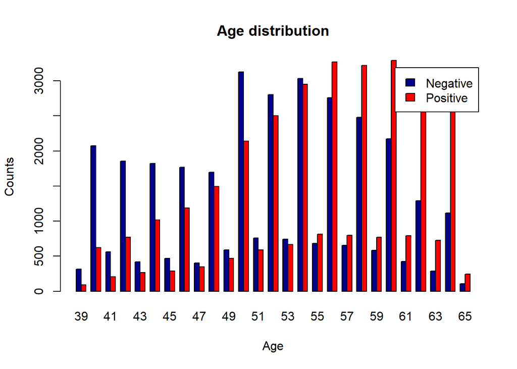

#### We see that most people who are suffering from cardio vascular diseases are of the age 60, followed by 56.Majorly, people belonging to the age group 50+ are suffering from the disease.

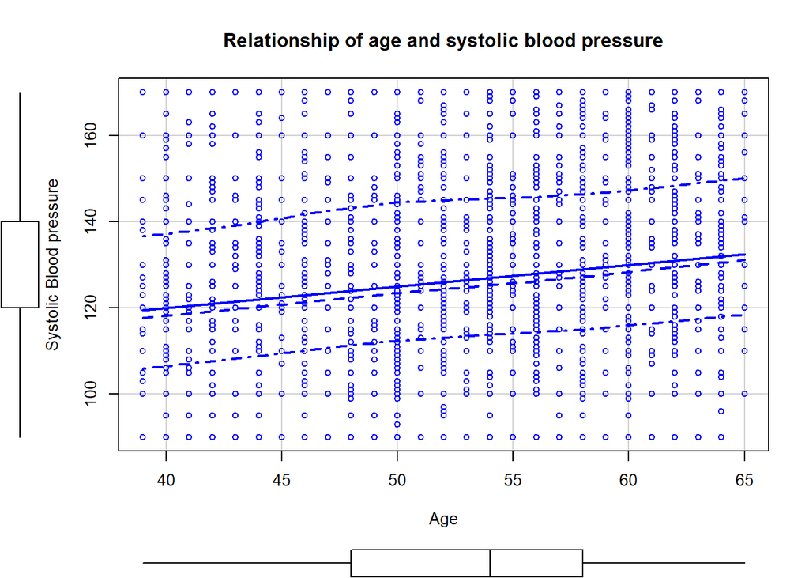

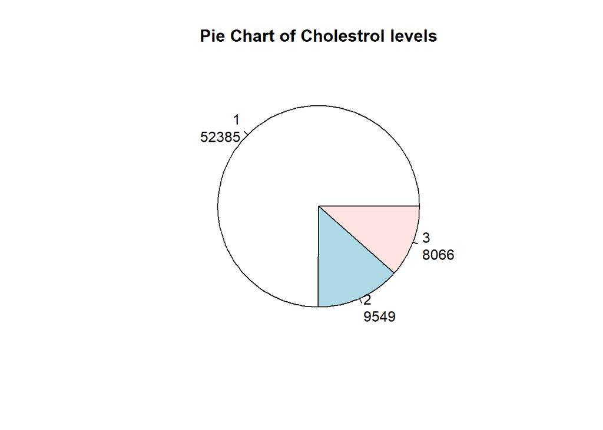

#### There are three cholestrol levels-

#### 1- Normal

#### 2- Above Normal

#### 3- Way above normal

#### The above pie chart shows that 3/4th of the population come under the normal cholestrol category.We see that most people who are suffering from cardio vascular diseases are of the age 60, followed by 56.Majorly, people belonging to the age group 50+ are suffering from the disease.

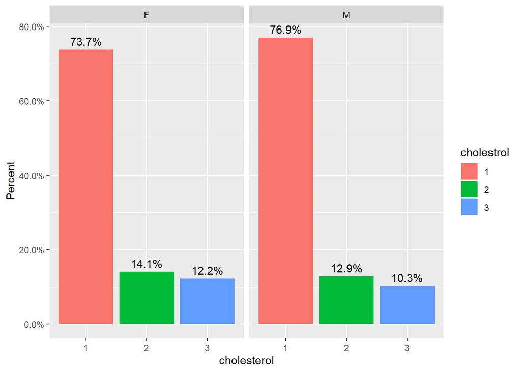

[figure not shown]

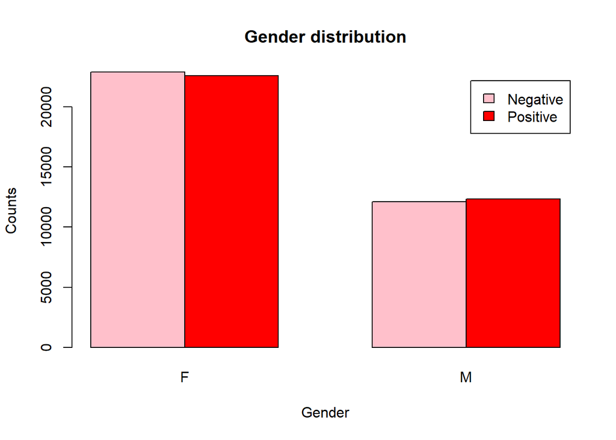

#### The above graph suggests that there are higher number of cases for women, but there are higher number of negative cases for women and higher number of positive cases for men.

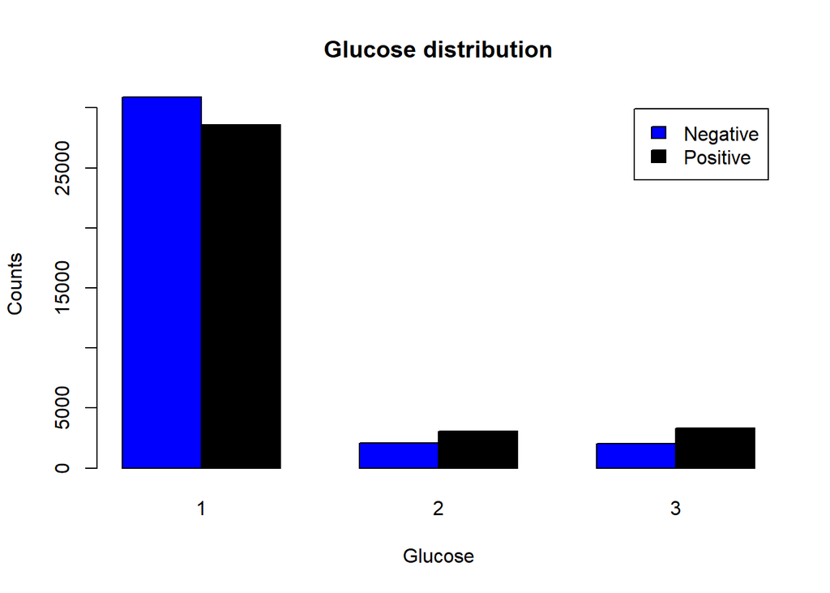

#### There are three Glucose levels-

#### 1- Normal

#### 2- Above Normal

#### 3- Way above normal

#### The above graph suggests that, the majority of the population comes under normal glucose level. Additionally, for normal glucose levels the chances of having cardio-vascular disease is less whereas for above normal glucose levels the chances of having a cardio-vascular disease is more.

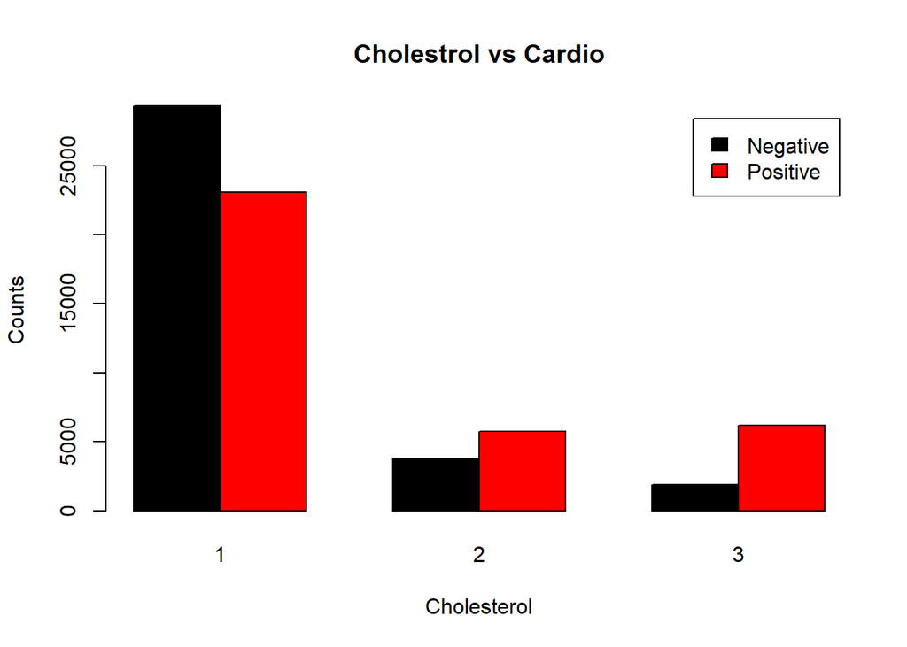

#### The above graph suggests that, the majority of the population comes under normal glucose level. Additionally, for normal Cholesterol levels the chances of having cardio-vascular disease is less whereas for above normal cholesterol levels the chances of having a cardio-vascular disease is more.

## **Chapter 4: Data Division & Statistical Tests**

#### we are dividing the data into test and train.

```
##
##  Welch Two Sample t-test
##
## data:  train_cd$age by train_cd$cardio
## t = -51.976, df = 45131, p-value < 2.2e-16
## alternative hypothesis: true difference in means is not equal to 0
## 95 percent confidence interval:
##  -3.322162 -3.080708
## sample estimates:
## mean in group Negative mean in group Positive
##               51.74971               54.95115
```

#### Strong significance

#### Statistical Significance between Height & Cardio Vascular Disease risk

```
##
##  Welch Two Sample t-test
##
## data:  train_cd$height by train_cd$cardio
## t = 1.3103, df = 45240, p-value = 0.1901
## alternative hypothesis: true difference in means is not equal to 0
## 95 percent confidence interval:
##  -0.04672825  0.23518748
## sample estimates:
## mean in group Negative mean in group Positive
##               164.4264               164.3321
```

#### Statistical Significance between Weight & Cardio Vascular Disease risk

```
##
##  Welch Two Sample t-test
##
## data:  train_cd$weight by train_cd$cardio
## t = -39.901, df = 45094, p-value < 2.2e-16
## alternative hypothesis: true difference in means is not equal to 0
## 95 percent confidence interval:
##  -5.019078 -4.549075
## sample estimates:
## mean in group Negative mean in group Positive
##               71.35354               76.13762
```

#### Strong significance

```
##
##  Welch Two Sample t-test
##
## data:  train_cd$bmi by train_cd$cardio
## t = -41.469, df = 44874, p-value < 2.2e-16
## alternative hypothesis: true difference in means is not equal to 0
## 95 percent confidence interval:
##  -1.917445 -1.744369
## sample estimates:
## mean in group Negative mean in group Positive
##               26.41639               28.24729
```

#### Strong significance

#### Statistical Significance between Systolic & Cardio Vascular Disease

```
##
##  Welch Two Sample t-test
##
## data:  train_cd$ap_hi by train_cd$cardio
## t = -103.99, df = 42003, p-value < 2.2e-16
## alternative hypothesis: true difference in means is not equal to 0
## 95 percent confidence interval:
##  -14.20551 -13.67990
## sample estimates:
## mean in group Negative mean in group Positive
##               119.6337               133.5764
```

#### Strong significance

#### Statistical Significance between Diastolic & Cardio Vascular Disease

```
##
##  Welch Two Sample t-test
##
## data:  train_cd$ap_lo by train_cd$cardio
## t = -82.214, df = 43111, p-value < 2.2e-16
## alternative hypothesis: true difference in means is not equal to 0
## 95 percent confidence interval:
##  -6.212403 -5.923088
## sample estimates:
## mean in group Negative mean in group Positive
##               78.82083               84.88858
```

#### Strong significance

#### Statistical Significance between Cholestrol & Cardio Vascular Disease

```
##
##  Pearson's Chi-squared test
##
## data:  train_cd$cholesterol and train_cd$cardio
## X-squared = 2083.8, df = 2, p-value < 2.2e-16
```

#### Strong significance

#### Statistical Significance between Glucose & Cardio Vascular Disease

```
##
##  Pearson's Chi-squared test
##
## data:  train_cd$gluc and train_cd$cardio
## X-squared = 352.42, df = 2, p-value < 2.2e-16
```

#### Strong significance

```
##
##  Pearson's Chi-squared test with Yates' continuity correction
##
## data:  train_cd$alco and train_cd$cardio
## X-squared = 1.2576, df = 1, p-value = 0.2621
```

#### Statistical Significance between Physical Activity & Cardio Vascular Disease risk

```
##
##  Pearson's Chi-squared test with Yates' continuity correction
##
## data:  train_cd$active and train_cd$cardio
## X-squared = 55.057, df = 1, p-value = 1.171e-13
```

#### Strong significance

## **Chapter 5: Models**

#### Logistic Regression

```
##
## Call:
## glm(formula = cardio ~ bmi + weight + ap_hi + height + glucnorm +
##     glucabovenorm + smoke + alco + active + cholnormal + cholabovenorm,
##     family = binomial(logit), data = train_cd)
##
## Deviance Residuals:
##     Min       1Q   Median       3Q      Max
## -2.9435  -0.9324  -0.3470   0.9264   2.4496
##
## Coefficients:
##                 Estimate Std. Error z value Pr(>|z|)
## (Intercept)   -6.3886944  1.4322319  -4.461 8.17e-06 ***
## bmi           -0.0117626  0.0254775  -0.462   0.6443
## weight         0.0172932  0.0096301   1.796   0.0725 .
## ap_hi          0.0647714  0.0008574  75.547  < 2e-16 ***
## height        -0.0112110  0.0087592  -1.280   0.2006
## glucnorm       0.3188433  0.0486657   6.552 5.69e-11 ***
## glucabovenorm  0.3571501  0.0628205   5.685 1.31e-08 ***
## smoke1        -0.1743300  0.0410344  -4.248 2.15e-05 ***
## alco1         -0.2165514  0.0512828  -4.223 2.41e-05 ***
## active1       -0.2256513  0.0266110  -8.480  < 2e-16 ***
## cholnormal    -1.1421543  0.0438760 -26.031  < 2e-16 ***
## cholabovenorm -0.7625811  0.0513677 -14.846  < 2e-16 ***
## ---
## Signif. codes:  0 '***' 0.001 '**' 0.01 '*' 0.05 '.' 0.1 ' ' 1
##
## (Dispersion parameter for binomial family taken to be 1)
##
##     Null deviance: 62789  on 45292  degrees of freedom
## Residual deviance: 51709  on 45281  degrees of freedom
## AIC: 51733
##
## Number of Fisher Scoring iterations: 4
```

#### As you can see the factors we have used to build model is giving results . For most of the variables the p value is low that means they are effective in predicting the cario deseas e. bmi and height are 2 variables which are not significant . alos the diffrence in value of null deviance and residual deviance is high . which means model is fitting.

```
## Start:  AIC=51733.26
## cardio ~ bmi + weight + ap_hi + height + glucnorm + glucabovenorm +
##     smoke + alco + active + cholnormal + cholabovenorm
##
##                 Df Deviance   AIC
## - bmi            1    51709 51731
## - height         1    51711 51733
## <none>                51709 51733
## - weight         1    51712 51734
## - alco           1    51727 51749
## - smoke          1    51727 51749
## - glucabovenorm  1    51742 51764
## - glucnorm       1    51752 51774
## - active         1    51781 51803
## - cholabovenorm  1    51936 51958
## - cholnormal     1    52452 52474
## - ap_hi          1    59221 59243
##
## Step:  AIC=51731.47
## cardio ~ weight + ap_hi + height + glucnorm + glucabovenorm +
##     smoke + alco + active + cholnormal + cholabovenorm
##
##                 Df Deviance   AIC
## <none>                51709 51731
## + bmi            1    51709 51733
## - alco           1    51727 51747
## - smoke          1    51728 51748
## - height         1    51732 51752
## - glucabovenorm  1    51742 51762
## - glucnorm       1    51753 51773
## - active         1    51781 51801
## - weight         1    51906 51926
## - cholabovenorm  1    51937 51957
## - cholnormal     1    52452 52472
## - ap_hi          1    59221 59241
```

[output not shown]

[output not shown]

```
##  [1] "aic"               "anova"             "boundary"
##  [4] "call"              "coefficients"      "contrasts"
##  [7] "control"           "converged"         "data"
## [10] "deviance"          "df.null"           "df.residual"
## [13] "effects"           "family"            "fitted.values"
## [16] "formula"           "iter"              "linear.predictors"
## [19] "method"            "model"             "null.deviance"
## [22] "offset"            "prior.weights"     "qr"
## [25] "R"                 "rank"              "residuals"
## [28] "terms"             "weights"           "xlevels"
## [31] "y"
```

```
## Stepwise Model Path
## Analysis of Deviance Table
##
## Initial Model:
## cardio ~ bmi + weight + ap_hi + height + glucnorm + glucabovenorm +
##     smoke + alco + active + cholnormal + cholabovenorm
##
## Final Model:
## cardio ~ weight + ap_hi + height + glucnorm + glucabovenorm +
##     smoke + alco + active + cholnormal + cholabovenorm
##
##
##    Step Df  Deviance Resid. Df Resid. Dev      AIC
## 1                        45281   51709.26 51733.26
## 2 - bmi  1 0.2130953     45282   51709.47 51731.47
```

#### As we can see the step aic functio has removed bmi , from the model and gave our best predictors.Now we gonna run our model again by removing BMI and compare it as well.

```
##
## Call:
## glm(formula = cardio ~ weight + ap_hi + height + glucnorm + glucabovenorm +
##     smoke + alco + active + cholnormal + cholabovenorm, family = binomial(logit),
##     data = train_cd)
##
## Deviance Residuals:
##     Min       1Q   Median       3Q      Max
## -2.9481  -0.9322  -0.3462   0.9265   2.4493
##
## Coefficients:
##                 Estimate Std. Error z value Pr(>|z|)
## (Intercept)   -7.0387392  0.2626270 -26.801  < 2e-16 ***
## weight         0.0128677  0.0009195  13.994  < 2e-16 ***
## ap_hi          0.0647736  0.0008574  75.550  < 2e-16 ***
## height        -0.0072284  0.0015173  -4.764 1.90e-06 ***
## glucnorm       0.3187119  0.0486650   6.549 5.79e-11 ***
## glucabovenorm  0.3572328  0.0628211   5.687 1.30e-08 ***
## smoke1        -0.1739742  0.0410189  -4.241 2.22e-05 ***
## alco1         -0.2164706  0.0512756  -4.222 2.42e-05 ***
## active1       -0.2256003  0.0266106  -8.478  < 2e-16 ***
## cholnormal    -1.1421835  0.0438762 -26.032  < 2e-16 ***
## cholabovenorm -0.7623916  0.0513671 -14.842  < 2e-16 ***
## ---
## Signif. codes:  0 '***' 0.001 '**' 0.01 '*' 0.05 '.' 0.1 ' ' 1
##
## (Dispersion parameter for binomial family taken to be 1)
##
##     Null deviance: 62789  on 45292  degrees of freedom
## Residual deviance: 51709  on 45282  degrees of freedom
## AIC: 51731
##
## Number of Fisher Scoring iterations: 4
```

#### As we can see there AIC value for 1st and second model is almost same which means BMI was not impacting the model.

[output not shown]

```
##                    yhat0     yhat1 y0 y1
## [0.0389,0.216] 3816.0762  713.9238  0  0
## (0.216,0.314]  3342.2506 1188.7494  0  0
## (0.314,0.344]  3034.7139 1505.2861  0  0
## (0.344,0.375]  2903.0941 1615.9059  0  0
## (0.375,0.425]  2731.1631 1795.8369  0  0
## (0.425,0.528]  2372.7571 2159.2429  0  0
## (0.528,0.651]  1870.7899 2666.2101  0  0
## (0.651,0.752]  1356.9009 3161.0991  0  0
## (0.752,0.863]   869.6322 3659.3678  0  0
## (0.863,0.988]   396.6220 4133.3780  0  0
```

```
## $concordance
## [1] 0.7757423
##
## $num_concordant
## [1] 17531
##
## $discordance
## [1] 0.2241692
##
## $num_discordant
## [1] 5066
##
## $tie_rate
## [1] 8.849949e-05
##
## $num_tied
## [1] 2
##
## $somers_D
## [1] 0.5515731
##
## $Gamma
## [1] 0.5516219
```

```
##        weight         ap_hi        height      glucnorm glucabovenorm
##      1.174514      1.044624      1.168127      2.517959      2.225468
##         smoke          alco        active    cholnormal cholabovenorm
##      1.174439      1.140902      1.002656      2.930894      2.641145
```

#### adj-R square would be totally irrelevant in case of logistic regression because we model the log odds ratio and it becomes very difficult in terms of explain ability.This is where concordance steps in to help. Concordance tells us the association between actual values and the values fitted by the model in percentage terms. Concordance is defined as the ratio of number of pairs where the 1 had a higher model score than the model score of zero to the total number of 1-0 pairs possible. A higher value for concordance (60-70%) means a better fitted model. However, a very large value for concordance (85-95%) could also suggest that the model is over-fitted and needs to be re-aligned to explain the entire population. so as we can see our model have 77 % of concordance whcih means its a good fit.

#### Moving over somers d if you see it is around 0.55 . Somers’ D is an index that you want to be closer to 1 and farther from −1. So we can say that our model is good fitted .

```
##  [1] "age"           "gender"        "height"        "weight"
##  [5] "ap_hi"         "ap_lo"         "cholesterol"   "gluc"
##  [9] "smoke"         "alco"          "active"        "cardio"
## [13] "bmi"           "cholnormal"    "cholabovenorm" "glucnorm"
## [17] "glucabovenorm" "Prob"
```

```
## [1] 0.4989513
```

```
## [1] 0.4997658
```

#### Decision Tree

### We use the packages ‘rpart’ and ‘rpart.plot’ inorder to compute and plot the decision trees. The rpart() uses our target feature (cardio) against other features.

#### We use the packages ‘rattle’, ‘rpart.plot’ and ‘RColorBrewer’, to create a more clean tree with the different probablilities of the possiblilities of Yes and No of attaining CVD.

#### To check for accuracy, use the predict() and use the accuracy formula.

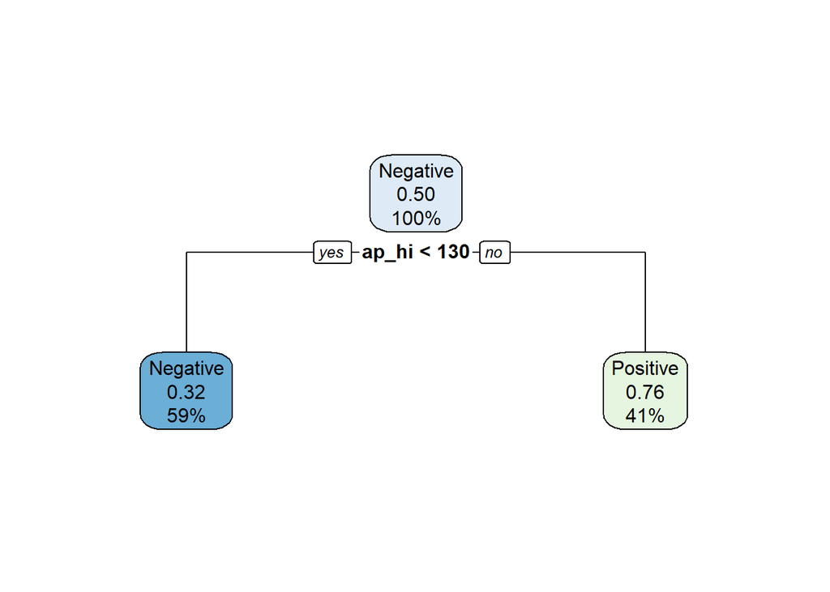

[figure not shown]

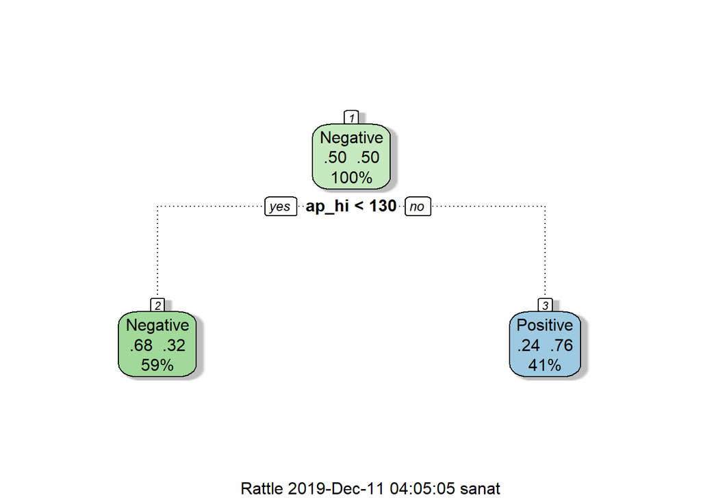

```
##
## Classification tree:
## rpart(formula = cardio ~ ., data = train_cd, method = "class")
##
## Variables actually used in tree construction:
## [1] ap_hi
##
## Root node error: 22599/45293 = 0.49895
##
## n= 45293
##
##        CP nsplit rel error  xerror      xstd
## 1 0.42413      0   1.00000 1.00482 0.0047086
## 2 0.01000      1   0.57587 0.57591 0.0042616
```

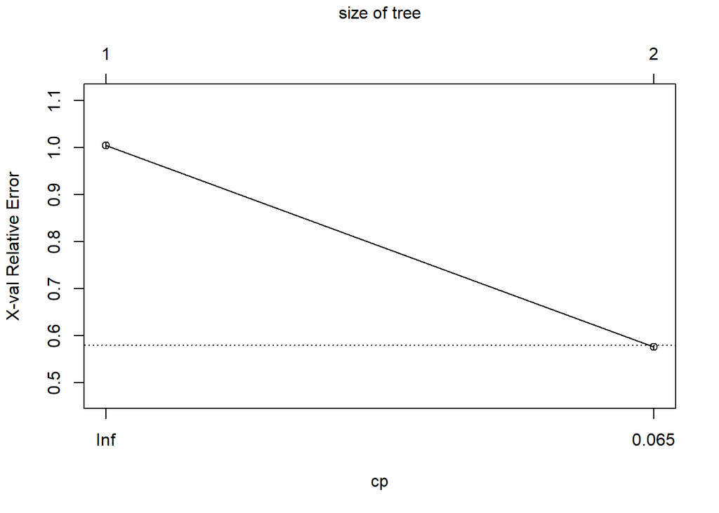

```
## Call:
## rpart(formula = cardio ~ ., data = train_cd, method = "class")
##   n= 45293
##
##          CP nsplit rel error    xerror        xstd
## 1 0.4241338      0 1.0000000 1.0048232 0.004708632
## 2 0.0100000      1 0.5758662 0.5759104 0.004261580
##
## Variable importance
##       ap_hi       ap_lo         bmi cholesterol  cholnormal      weight
##          48          29           6           6           6           6
##
## Node number 1: 45293 observations,    complexity param=0.4241338
##   predicted class=Negative  expected loss=0.4989513  P(node) =1
##     class counts: 22694 22599
##    probabilities: 0.501 0.499
##   left son=2 (26722 obs) right son=3 (18571 obs)
##   Primary splits:
##       ap_hi       < 129.5    to the left,  improve=4226.7220, (0 missing)
##       ap_lo       < 86.5     to the left,  improve=2835.0150, (0 missing)
##       cholesterol splits as  LRR,          improve= 903.8036, (0 missing)
##       cholnormal  < 0.5      to the right, improve= 903.8036, (0 missing)
##       age         < 54.5     to the left,  improve= 893.2461, (0 missing)
##   Surrogate splits:
##       ap_lo       < 83.5     to the left,  agree=0.837, adj=0.602, (0 split)
##       bmi         < 28.67637 to the left,  agree=0.643, adj=0.128, (0 split)
##       cholesterol splits as  LRR,          agree=0.641, adj=0.124, (0 split)
##       cholnormal  < 0.5      to the right, agree=0.641, adj=0.124, (0 split)
##       weight      < 80.3     to the left,  agree=0.639, adj=0.118, (0 split)
##
## Node number 2: 26722 observations
##   predicted class=Negative  expected loss=0.3188758  P(node) =0.5899808
##     class counts: 18201  8521
##    probabilities: 0.681 0.319
##
## Node number 3: 18571 observations
##   predicted class=Positive  expected loss=0.2419364  P(node) =0.4100192
##     class counts:  4493 14078
##    probabilities: 0.242 0.758
```

```
##           predict_dt
##            Negative Positive
##   Negative     9959     2368
##   Positive     4645     7735
```

```
## [1] 0.7161533
```

#### Random Forest

```
##
## Call:
##  randomForest(formula = cardio ~ . - weight - height, data = train_cd,      ntree = 500, mtry = 3, importance = TRUE)
##                Type of random forest: classification
##                      Number of trees: 500
## No. of variables tried at each split: 3
##
##         OOB estimate of  error rate: 26.61%
## Confusion matrix:
##          Negative Positive class.error
## Negative    17878     4816   0.2122147
## Positive     7238    15361   0.3202797
```

```
## $names
##  [1] "call"            "type"            "predicted"
##  [4] "err.rate"        "confusion"       "votes"
##  [7] "oob.times"       "classes"         "importance"
## [10] "importanceSD"    "localImportance" "proximity"
## [13] "ntree"           "mtry"            "forest"
## [16] "y"               "test"            "inbag"
## [19] "terms"
##
## $class
## [1] "randomForest.formula" "randomForest"
```

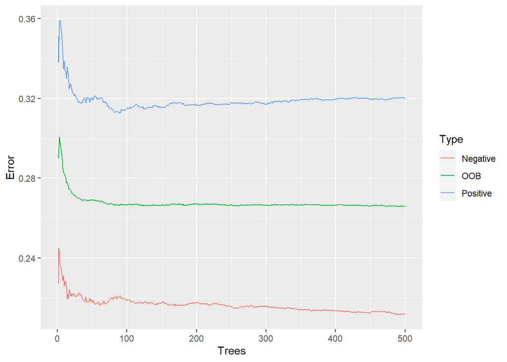

#### Here we can see that error rate is the most stable around 500 trees for both the results as well as OOB. Therefore, we will continue with the default value.

```
##    Min. 1st Qu.  Median    Mean 3rd Qu.    Max.
##  0.2666  0.2706  0.2812  0.2837  0.2972  0.3040
```

#### Here we can see that, we get the best result for mtry= 3 in terms of Out of Bag error rate

#### The training set gives an accuracy of 76.86%

#### The test set gives an accuracy of 73.58%

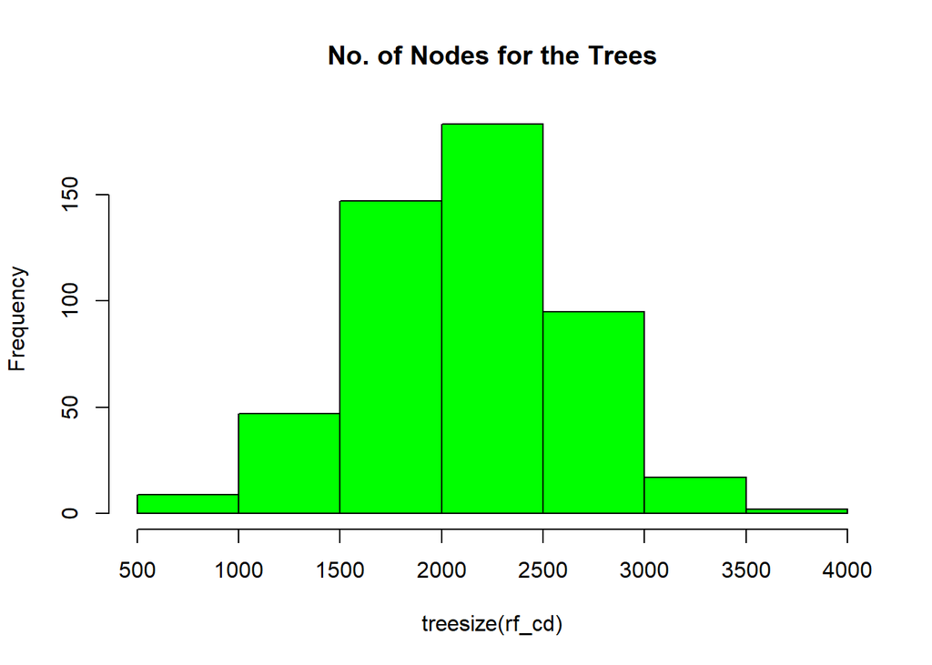

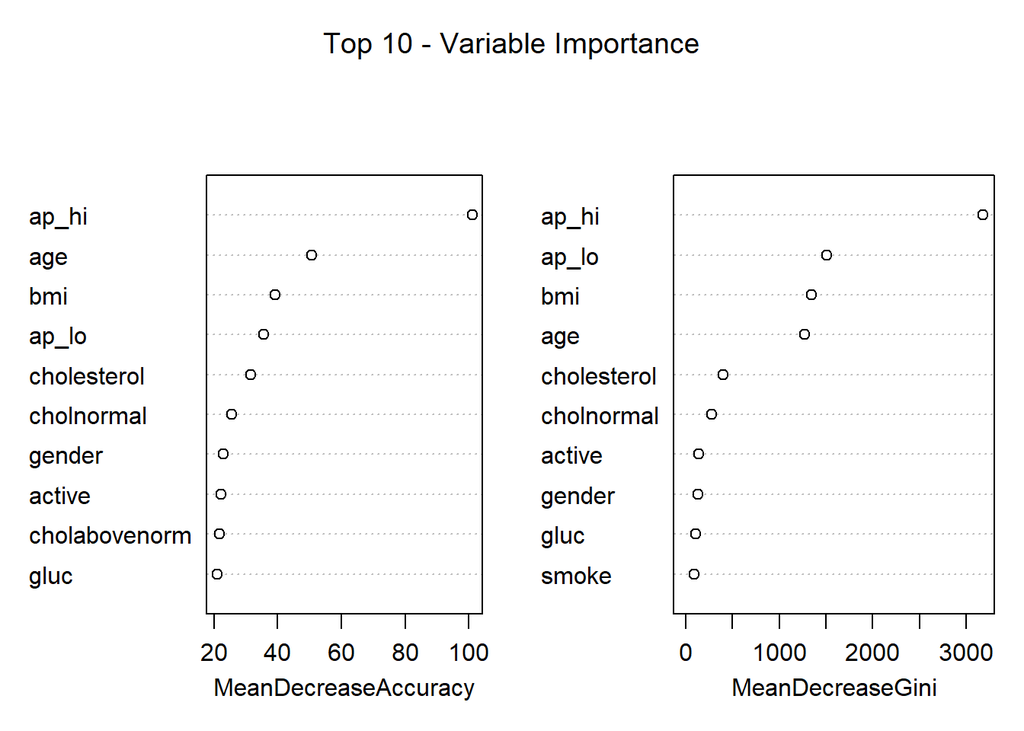

```
##                Negative   Positive MeanDecreaseAccuracy MeanDecreaseGini
## age           43.354429  50.230448             50.59196       1270.73288
## gender        22.573674   1.053064             23.03423        130.42548
## ap_hi         91.200865  60.494555            101.05443       3171.73374
## ap_lo         28.085276  11.512346             35.63436       1506.09144
## cholesterol   33.236885 -11.993046             31.56640        402.37205
## gluc          23.782328 -11.324021             20.94264        107.06574
## smoke         16.987450   3.988359             20.13691         91.33528
## alco          15.900712  -3.200444             12.50947         82.84592
## active        14.189683  18.843933             22.19375        136.98802
## bmi           34.239875   4.649418             39.11706       1348.11899
## cholnormal    25.459836 -18.068669             25.57502        276.73331
## cholabovenorm 22.975938 -21.391740             21.87149         80.39197
## glucnorm      20.182113  -9.787935             19.53454         70.77350
## glucabovenorm  8.720641   3.265859             13.75621         42.97736
```

```
##  [1] 201695  67263 134646 107606  17455  35958  48670  45718  56980 267474
## [11]  10549  13261  26919  22752
```

#### The variable importance plot shows that in terms of Mean Decrease Gini value we get Systolic(Ap_hi), Diastolic(Ap_lo),bm, age and cholesterol to be our top 5 predictors

## **Chapter 5: Top performing features**

#### Comparing our 3 models, we found that the most important features are:

#### Ap_hi (Systolic blood pressure)

#### Cholesterol

#### Age

#### Ap_lo (Diastolic blood pressure)

#### BMI

#### Glucose

## **Chapter 6: Limitations**

#### Lack of more detailed factors such as genetics (family history), complains of chest pain, shock factor, etc.

#### Time periods for when a factor acted up were not available.

#### Separate data for both types of cholesterol (HDL and LDL), would have helped better in the classification.

## **Chapter 7: Conclusion**

#### Through our analysis, it was clear that most of the important features that run a risk to affect CVD are those that can be directly or indirectly affected by our health choices.

#### Some factors, however, are not in our control. After the age of 55, our chances to acquire a CVD increases greatly. This risk is greater for men than women between the ages of 40 – 59.

#### BMI is another factor that affects getting CVD. Considering this factor in terms of gender, middle-aged women tend to have a higher BMI than men. This is because, the body fat mass in middle-aged women tends to increase in general. M (30%) W (42%).

#### Features such as alcohol, smoking and physical activity are indirectly related to running a risk of CVD.

#### In general take care of your health and be happy.